# Spatial interaction models with R

# 1 Prerequisites

You need to have [installed R](https://cran.r-project.org/) and a suitable editor such as [RStudio](https://www.rstudio.com/products/rstudio/download/preview/) or [VSCode with R plugin](https://github.com/REditorSupport/vscode-R). See the package’s [README](https://robinlovelace.github.io/simodels/) for instructions on installing the {simodels} package.

```r
library(simodels)
library(dplyr)
```

```r
library(ggplot2)
library(sf)
```

# 2 Input data

This tutorial builds on a [reproducible](https://github.com/adamdennett/SIModelling/blob/SIModelling-Edits/SimAus2.Rmd) guide to SIMs in R (Dennett 2018). We start by importing open access data representing movement between zones in Australia (thanks to Adam Dennett for making the files accessible):

```r
# To get the data (pre-loaded in the package)
u1 = "https://github.com/Robinlovelace/simodels/releases/download/0.0.1/zones_aus.geojson"
zones_aus = sf::read_sf(u1)
u2 = "https://www.dropbox.com/s/wi3zxlq5pff1yda/AusMig2011.csv?raw=1"
od_aus = read.csv(u2)
```

Let’s take a quick look at and ‘minimize’ these input datasets before modelling them with SIMs:

```r
dim(zones_aus)
```

```
#> [1] 9 7
```

```r
names(zones_aus)
```

```
#> [1] "GCCSA_CODE" "GCC_CODE16" "GCCSA_NAME" "STATE_CODE" "STATE_NAME"
#> [6] "AREA_SQKM"  "geometry"
```

```r
key_zone_names = c("GCCSA_CODE", "GCCSA_NAME", "AREA_SQKM")
zones = zones_aus[key_zone_names]
head(zones, 2)
```

```
#> Simple feature collection with 2 features and 3 fields
#> Geometry type: MULTIPOLYGON
#> Dimension:     XY
#> Bounding box:  xmin: 140.9657 ymin: -38.87213 xmax: 153.6056 ymax: -28.16441
#> Geodetic CRS:  GDA94
#> # A tibble: 2 × 4
#>   GCCSA_CODE GCCSA_NAME   AREA_SQKM                                     geometry
#>   <chr>      <chr>            <dbl>                           <MULTIPOLYGON [°]>
#> 1 1RNSW      Rest of NSW    788443. (((153.008 -28.34026, 153.5522 -28.16441, 1…
#> 2 2RVIC      Rest of Vic.   217503. (((149.9763 -37.50503, 147.7061 -37.99805, …
```

```r
dim(od_aus)
```

```
#> [1] 225  13
```

```r
names(od_aus)
```

```
#>  [1] "Origin"          "Orig_code"       "Destination"     "Dest_code"
#>  [5] "Flow"            "vi1_origpop"     "wj1_destpop"     "vi2_origunemp"
#>  [9] "wj2_destunemp"   "vi3_origmedinc"  "wj3_destmedinc"  "vi4_origpctrent"
#> [13] "wj4_destpctrent"
```

```r
key_od_names = c("Orig_code", "Dest_code", "Flow")
od = od_aus[key_od_names]
head(od, 2)
```

```
#>   Orig_code Dest_code    Flow
#> 1     1GSYD     1GSYD 3395015
#> 2     1GSYD     1RNSW   91031
```

Note: a useful convention with ‘long form’ OD datasets is for the first two columns to contain zone IDs that correspond to values in the first column of the zone dataset. The R package [{od}](https://itsleeds.github.io/od/), on which {simodels} builds, assumes that inputs to its functions are in this form.

It is a good idea to verify that the origin and destination codes in the `od` dataset match the zone codes in `zones`:

```r
summary(od[[1]] %in% zones[[1]])
```

```
#>    Mode   FALSE    TRUE
#> logical      90     135
```

```r
summary(od[[2]] %in% zones[[1]])
```

```
#>    Mode   FALSE    TRUE
#> logical      90     135
```

# 3 Preparing a SIM

Key to the workings of the {simodels} package is the conversion of geographic objects representing origins and destinations into an OD dataset. In this case, we already have an OD dataset, so this step is less relevant. However, we will take this step in any case because many SIMs start without such a comprehensive OD dataset as we have in this case.

Prepare the OD dataset as follows:

```r
od_sim = si_to_od(origins = zones, destinations = zones)
```

```
#> Maximum distance is > 100km. The 'cheap' measure is inaccurate over such
#> large distances, you'd likely be better using a different 'measure'.
```

```r
names(od_sim)
```

```
#> [1] "O"                      "D"                      "distance_euclidean"
#> [4] "origin_GCCSA_NAME"      "origin_AREA_SQKM"       "destination_GCCSA_NAME"
#> [7] "destination_AREA_SQKM"  "geometry"
```

Note that the output has duplicate columns: `si_to_od()` joins data from the origin and destination objects into the resulting OD object.

# 4 An unconstrained SIM

A simplistic SIM - in this case an inverse power distance decay function (negative exponential is another commonly used decay function) - can be created just based on the distance between points:

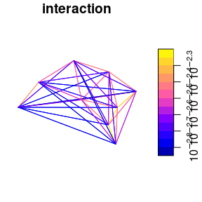

```r
si_power = function(d, beta) (d / 1000)^beta
od_calculated = si_calculate(
  od_sim,
  fun = si_power,
  d = distance_euclidean,
  beta = -0.8
  )
plot(od_calculated["interaction"], logz = TRUE)
```

This approach, ignoring all variables at the level of trip origins and destinations, results in flow estimates with no units. Before learning how to run constrained SIMs, let’s scale the result by the total flow and see how far we are from reality, just focussing on the interzonal OD pairs:

```r
od_interzonal = od %>%
  filter(Orig_code != Dest_code)
od_calculated_interzonal = od_calculated %>%
  filter(O != D)
scale_factor = sum(od_interzonal$Flow) /
  sum(od_calculated_interzonal$interaction)
od_calculated_interzonal = od_calculated_interzonal %>%
  mutate(interaction_scaled = interaction * scale_factor)
od_joined = inner_join(
  od_calculated_interzonal,
  od %>% rename(O = Orig_code, D = Dest_code)
  )
```

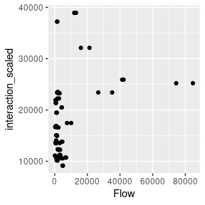

```r
od_joined %>%
  ggplot() +
  geom_point(aes(Flow, interaction_scaled))
```

```r
cor(od_joined$Flow, od_joined$interaction_scaled)^2
```

```
#> [1] 0.1195504
```

The results show that a simple unconstrained model, without any parameter fitting, can explain less than 20% of the variability in flows. We can do better!

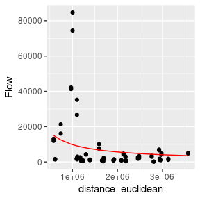

```r
od_joined %>%
  mutate(decay = distance_euclidean^-0.8) %>%
  mutate(decay = decay * (sum(Flow) / sum(decay))) %>%
  ggplot() +
  geom_point(aes(distance_euclidean, Flow)) +
  geom_line(aes(distance_euclidean, decay), colour = "red")
```

# 5 A production constrained SIM

The first logical way to improve model fit is to run a production constrained model. To do that, we’ll first calculate the total number of people leaving each zone and then use the `constraint_production` argument:

```r
od_originating = od_joined %>%
  group_by(O) %>%
  mutate(originating_per_zone = sum(Flow)) %>%
  ungroup()
```

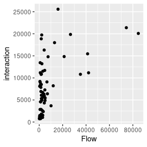

```r
od_constrained_p = si_calculate(
  od_originating,
  fun = si_power,
  d = distance_euclidean,
  beta = -0.8,
  constraint_production = originating_per_zone
  )
od_constrained_p %>%
  ggplot() +
  geom_point(aes(Flow, interaction))
```

```r
cor(od_constrained_p$Flow, od_constrained_p$interaction)^2
```

```
#> [1] 0.3127995
```

Progress! We have more than doubled the predictive ability of our model by using a ‘production constrained’ SIM, as defined mathematically in the [`simodels-first-principles` vignette](https://robinlovelace.github.io/simodels/articles/sims-first-principles.html).

# 6 Training a SIM

An advantage of the flow data used in this example is that we already know the interaction. (This raises the question of why a SIM is needed, answer: to test our models and demonstrate the techniques.)

We can do this using the `nls()` function as follows:

```r
library(minpack.lm)
f = Flow ~ a * (distance_euclidean)^b
m = nlsLM(
  formula = f,
  data = od_originating,
  )
m
```

```
#> Nonlinear regression model
#>   model: Flow ~ a * (distance_euclidean)^b
#>    data: od_originating
#>          a          b
#>  2.936e+07 -5.779e-01
#>  residual sum-of-squares: 1.482e+10
#>
#> Number of iterations till stop: 50
#> Achieved convergence tolerance: 1.49e-08
#> Reason stopped: Number of iterations has reached `maxiter' == 50.
```

```r
# Nonlinear regression model
#   model: Flow ~ a * (distance_euclidean)^b
#    data: od_originating
#          a          b
#  2.182e+07 -5.801e-01
```

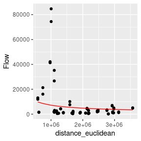

```r
od_joined %>%
  mutate(decay = distance_euclidean^-5.801e-01) %>%
  mutate(decay = decay * 2.182e+07) %>%
  ggplot() +
  geom_point(aes(distance_euclidean, Flow)) +
  geom_line(aes(distance_euclidean, decay), colour = "red")
```

```r
od_pred = si_predict(od_originating, model = m)
cor(od_pred$Flow, od_pred$interaction)^2
```

```
#> [1] 0.1234891
```

```r
od_pred_const = si_predict(od_originating, model = m,
  constraint_production = originating_per_zone)
cor(od_pred_const$Flow, od_pred_const$interaction)^2
```

```
#> [1] 0.2701773
```

```r
library(tmap)
ttm()
```

```
#> tmap mode set to interactive viewing
```

```r
tm_shape(od_pred_const) +
  tm_lines("interaction_scaled", palette = "viridis")
```

[interactive chart not shown]

# References

Dennett, Adam. 2018. “Modelling Population Flows Using Spatial Interaction Models.” *Australian Population Studies* 2 (2): 33–58. https://doi.org/10.37970/aps.v2i2.38.